**Data Science with**

[figure not shown]

Jupyter Notebook version

# **Tidy data**

> *Happy families are all alike; every unhappy family is unhappy in its own way. Leo Tolstoy*

It is impossible to predict how data may be presented to the analyst. Nearly each data set will have its own features, peculiarities and errors and we must be ready to work with any data shape. The task is then to transform data so that it is in a standardised format ready to be analysed using a system of choice, in our case `Python`.

The quote above applies to data sets as: Tidy data sets are all alike; every messy data set is messy in its own way.

Hadley Wickham in his paper [Tidy Data](https://www.jstatsoft.org/article/view/v059i10/v59i10.pdf) defines the three main qualities of tidy data which standardise the process of dealing with any data set:

1. Each variable forms a column.
2. Each observation forms a row.
3. Each type of observational unit forms a table.

Qualities 1 and 2 are crucial for adequate and ease of use of `Python` packages for visualisation and analysis. Quality 3 is important in order to organise the data but it might be necessary to unify tables with related information at some point for analysis. For example, we may have a table with information about the response to a medical intervention for patients and another table with demographic data. But at some point they might need to be joined for analysis.

These three qualities are what the end product of the data tidying process must possess.

*Messy data* is data which is not tidy.

Applying the tidy data criteria standardises the structure of a data set, making exploration and analysis of data easier and less error-prone.

# **CASE STUDY.** Massachusetts Bay Transport Authority (MBTA) data from an excel file

Let us consider monthly transportation data in Boston, USA, consisting of monthly averages of weekday number of passengers (in thousands) by mode of transportation. A snapshot of part of the data (not all columns are included), in excel format, is below.

[figure not shown]

The variables in this study are mode of transportation, year, month, and weekday average number of trips.

Do this first:

```python
import pandas as pd
import numpy as np
import matplotlib.pyplot as plt
```

## Importing the data

The first row in the excel sheet is a title, so we skip this row when reading the data in.

```python
#we skip the first row as it is a title, also the NA character is "NA", not blank space which is the default value
mbta = pd.read_excel("DataFiles/mbta.xlsx", skiprows = [0], na_values = "NA")
#show the first 6 rows
mbta.head()
```

|  | Unnamed: 0 | mode | 2007-01 | 2007-02 | 2007-03 | 2007-04 | 2007-05 | 2007-06 | 2007-07 | 2007-08 | ... | 2011-01 | 2011-02 | 2011-03 | 2011-04 | 2011-05 | 2011-06 | 2011-07 | 2011-08 | 2011-09 | 2011-10 |
| --- | --- | --- | --- | --- | --- | --- | --- | --- | --- | --- | --- | --- | --- | --- | --- | --- | --- | --- | --- | --- | --- |
| 0 | 1 | All Modes by Qtr | NaN | NaN | 1187.653 | NaN | NaN | 1245.959 | NaN | NaN | ... | NaN | NaN | 1223.452 | NaN | NaN | 1302.414 | NaN | NaN | 1290.549 | NaN |
| 1 | 2 | Boat | 4.000 | 3.600 | 40.000 | 4.300 | 4.900 | 5.800 | 6.521 | 6.572 | ... | 3.140 | 3.284 | 3.674 | 4.251 | 4.431 | 5.474 | 6.581 | 6.733 | 5.003 | 4.484 |
| 2 | 3 | Bus | 335.819 | 338.675 | 339.867 | 352.162 | 354.367 | 350.543 | 357.519 | 355.479 | ... | 334.958 | 346.234 | 380.399 | 380.446 | 385.289 | 376.317 | 361.585 | 353.793 | 388.271 | 398.456 |
| 3 | 4 | Commuter Rail | 142.200 | 138.500 | 137.700 | 139.500 | 139.000 | 143.000 | 142.391 | 142.364 | ... | 128.396 | 125.463 | 134.374 | 134.169 | 136.140 | 135.581 | 132.410 | 130.616 | 136.901 | 128.720 |
| 4 | 5 | Heavy Rail | 435.294 | 448.271 | 458.583 | 472.201 | 474.579 | 477.032 | 471.735 | 461.605 | ... | 468.418 | 504.068 | 516.730 | 528.631 | 528.122 | 529.528 | 532.888 | 508.145 | 550.137 | 554.932 |

5 rows × 60 columns

```python
#show the last 6 rows
mbta.tail()
```

|  | Unnamed: 0 | mode | 2007-01 | 2007-02 | 2007-03 | 2007-04 | 2007-05 | 2007-06 | 2007-07 | 2007-08 | ... | 2011-01 | 2011-02 | 2011-03 | 2011-04 | 2011-05 | 2011-06 | 2011-07 | 2011-08 | 2011-09 | 2011-10 |
| --- | --- | --- | --- | --- | --- | --- | --- | --- | --- | --- | --- | --- | --- | --- | --- | --- | --- | --- | --- | --- | --- |
| 6 | 7 | Pct Chg / Yr | 0.020 | -0.040 | 0.114 | -0.002 | 0.049 | 0.096 | -0.037 | 0.004 | ... | -0.028 | 0.008 | 0.050 | 0.036 | 0.050 | 0.054 | 0.067 | 0.052 | 0.043 | 0.032 |
| 7 | 8 | Private Bus | 4.772 | 4.417 | 4.574 | 4.542 | 4.768 | 4.722 | 3.936 | 3.946 | ... | 2.213 | 2.570 | 2.559 | 2.762 | 2.776 | 2.815 | 2.671 | 2.655 | 2.843 | 2.967 |
| 8 | 9 | RIDE | 4.900 | 5.000 | 5.500 | 5.400 | 5.400 | 5.600 | 5.253 | 5.308 | ... | 6.735 | 7.463 | 8.387 | 8.145 | 8.059 | 8.377 | 7.902 | 8.071 | 8.318 | 8.598 |
| 9 | 10 | Trackless Trolley | 12.757 | 12.913 | 13.057 | 13.444 | 13.479 | 13.323 | 13.311 | 13.142 | ... | 11.104 | 11.695 | 12.601 | 12.599 | 12.291 | 12.128 | 11.060 | 11.091 | 12.332 | 12.297 |
| 10 | 11 | TOTAL | 1166.974 | 1191.639 | 1204.725 | 1247.105 | 1244.755 | 1246.129 | 1243.952 | 1223.323 | ... | 1153.413 | 1220.663 | 1286.660 | 1313.283 | 1302.884 | 1292.085 | 1286.107 | 1241.268 | 1348.754 | 1348.222 |

5 rows × 60 columns

```python
#display all the column names
cols = list(mbta.columns.values)
cols
```

```
['Unnamed: 0',
 'mode',
 '2007-01',
 '2007-02',
 '2007-03',
 '2007-04',
 '2007-05',
 '2007-06',
 '2007-07',
 '2007-08',
 '2007-09',
 '2007-10',
 '2007-11',
 '2007-12',
 '2008-01',
 '2008-02',
 '2008-03',
 '2008-04',
 '2008-05',
 '2008-06',
 '2008-07',
 '2008-08',
 '2008-09',
 '2008-10',
 '2008-11',
 '2008-12',
 '2009-01',
 '2009-02',
 '2009-03',
 '2009-04',
 '2009-05',
 '2009-06',
 '2009-07',
 '2009-08',
 '2009-09',
 '2009-10',
 '2009-11',
 '2009-12',
 '2010-01',
 '2010-02',
 '2010-03',
 '2010-04',
 '2010-05',
 '2010-06',
 '2010-07',
 '2010-08',
 '2010-09',
 '2010-10',
 '2010-11',
 '2010-12',
 '2011-01',
 '2011-02',
 '2011-03',
 '2011-04',
 '2011-05',
 '2011-06',
 '2011-07',
 '2011-08',
 '2011-09',
 '2011-10']
```

## Tidying the data

As can be seen, the first column of `mbta`, unnamed in the original excel file and named `Unnamed: 0` by `Python`, simply gives the row number which is irrelevant, as rows are identified by mode of transportation, so we will exclude it. In some cases, not this particular data set, rows don't have an identifier and so some sort of row id is needed. Also, the first row is a quarterly aggregation of the data and should not be mixed with monthly data by single mode of transportation. So we will exclude this first row of the data. The last row has totals by column so it will be excluded as well as it may cause errors to leave it. Row 7 has percentage change in the year, again a summary of the data which should not be in a tidy data set.

```python
#drop 1st, 7th and 11th rows and the first column
mbta.drop(index = [0,6,10], columns = 'Unnamed: 0', inplace = True)
mbta
```

|  | mode | 2007-01 | 2007-02 | 2007-03 | 2007-04 | 2007-05 | 2007-06 | 2007-07 | 2007-08 | 2007-09 | ... | 2011-01 | 2011-02 | 2011-03 | 2011-04 | 2011-05 | 2011-06 | 2011-07 | 2011-08 | 2011-09 | 2011-10 |
| --- | --- | --- | --- | --- | --- | --- | --- | --- | --- | --- | --- | --- | --- | --- | --- | --- | --- | --- | --- | --- | --- |
| 1 | Boat | 4.000 | 3.600 | 40.000 | 4.300 | 4.900 | 5.800 | 6.521 | 6.572 | 5.469 | ... | 3.140 | 3.284 | 3.674 | 4.251 | 4.431 | 5.474 | 6.581 | 6.733 | 5.003 | 4.484 |
| 2 | Bus | 335.819 | 338.675 | 339.867 | 352.162 | 354.367 | 350.543 | 357.519 | 355.479 | 372.598 | ... | 334.958 | 346.234 | 380.399 | 380.446 | 385.289 | 376.317 | 361.585 | 353.793 | 388.271 | 398.456 |
| 3 | Commuter Rail | 142.200 | 138.500 | 137.700 | 139.500 | 139.000 | 143.000 | 142.391 | 142.364 | 143.051 | ... | 128.396 | 125.463 | 134.374 | 134.169 | 136.140 | 135.581 | 132.410 | 130.616 | 136.901 | 128.720 |
| 4 | Heavy Rail | 435.294 | 448.271 | 458.583 | 472.201 | 474.579 | 477.032 | 471.735 | 461.605 | 499.566 | ... | 468.418 | 504.068 | 516.730 | 528.631 | 528.122 | 529.528 | 532.888 | 508.145 | 550.137 | 554.932 |
| 5 | Light Rail | 227.231 | 240.262 | 241.444 | 255.557 | 248.262 | 246.108 | 243.286 | 234.907 | 265.748 | ... | 198.450 | 219.886 | 227.935 | 242.280 | 225.776 | 221.865 | 231.010 | 220.164 | 244.949 | 237.768 |
| 7 | Private Bus | 4.772 | 4.417 | 4.574 | 4.542 | 4.768 | 4.722 | 3.936 | 3.946 | 4.329 | ... | 2.213 | 2.570 | 2.559 | 2.762 | 2.776 | 2.815 | 2.671 | 2.655 | 2.843 | 2.967 |
| 8 | RIDE | 4.900 | 5.000 | 5.500 | 5.400 | 5.400 | 5.600 | 5.253 | 5.308 | 5.609 | ... | 6.735 | 7.463 | 8.387 | 8.145 | 8.059 | 8.377 | 7.902 | 8.071 | 8.318 | 8.598 |
| 9 | Trackless Trolley | 12.757 | 12.913 | 13.057 | 13.444 | 13.479 | 13.323 | 13.311 | 13.142 | 14.393 | ... | 11.104 | 11.695 | 12.601 | 12.599 | 12.291 | 12.128 | 11.060 | 11.091 | 12.332 | 12.297 |

8 rows × 59 columns

Continuing with the tidying up of the data, we recall that the variables in this experiment are mode of transportation, year, month and monthly average number of passengers. Therefore, all column names, except for the first one, `mode`, are values of year and month combined.

```python
# melt all column name values, except the first one (the index), into the "year_month" column with the corresponding values in the column "NrPassengers"
mbta2 = mbta.melt('mode', var_name = "year_month", value_name = "NrPassengers")
mbta2.head()
```

|  | mode | year_month | NrPassengers |
| --- | --- | --- | --- |
| 0 | Boat | 2007-01 | 4.000 |
| 1 | Bus | 2007-01 | 335.819 |
| 2 | Commuter Rail | 2007-01 | 142.200 |
| 3 | Heavy Rail | 2007-01 | 435.294 |
| 4 | Light Rail | 2007-01 | 227.231 |

Next, the column `year_month` contains the values of two variables. We may want to keep the year in one column and month in another column.

```python
# new data frame with split value columns
new = mbta2['year_month'].str.split('-', n = 1, expand = True)
mbta3 = mbta2
```

```python
# making separate columns from new data frame
mbta3['year'] = new[0]
mbta3['month'] = new[1]
#drop year_month
mbta3.drop(columns = ['year_month'], inplace = True)
mbta3.head()
```

|  | mode | NrPassengers | year | month |
| --- | --- | --- | --- | --- |
| 0 | Boat | 4.000 | 2007 | 01 |
| 1 | Bus | 335.819 | 2007 | 01 |
| 2 | Commuter Rail | 142.200 | 2007 | 01 |
| 3 | Heavy Rail | 435.294 | 2007 | 01 |
| 4 | Light Rail | 227.231 | 2007 | 01 |

```python
mbta3.dtypes
```

```
mode             object
NrPassengers    float64
year             object
month            object
dtype: object
```

```python
#make columns year and month numeric
mbta3['year'] = pd.to_numeric(mbta3['year'])
mbta3['month'] = pd.to_numeric(mbta3['month'])
mbta3.dtypes
```

```
mode             object
NrPassengers    float64
year              int64
month             int64
dtype: object
```

```python
#create a column named day with 1s
mbta3 = mbta3.assign(day = 1)
#
mbta3['date'] = pd.to_datetime(mbta3[['year', 'month', 'day']])
mbta3.head()
```

|  | mode | NrPassengers | year | month | day | date |
| --- | --- | --- | --- | --- | --- | --- |
| 0 | Boat | 4.000 | 2007 | 1 | 1 | 2007-01-01 |
| 1 | Bus | 335.819 | 2007 | 1 | 1 | 2007-01-01 |
| 2 | Commuter Rail | 142.200 | 2007 | 1 | 1 | 2007-01-01 |
| 3 | Heavy Rail | 435.294 | 2007 | 1 | 1 | 2007-01-01 |
| 4 | Light Rail | 227.231 | 2007 | 1 | 1 | 2007-01-01 |

```python
print(mbta3.dtypes)
```

```
mode                    object
NrPassengers           float64
year                     int64
month                    int64
day                      int64
date            datetime64[ns]
dtype: object
```

The data is now tidy and ready to be explored.

Let us visualise the data.

We will mostly use the package `plotnine` to visualise the data as it is in line with the concept of tidy data.

For examples of visualisations using `pandas` see https://pandas.pydata.org/pandas-docs/version/0.22/visualization.html

## Visualisation using `plotnine`

![](pics/plotninelogo.png)

If you have used the package `ggplot2` in `R` you will have discovered high quality plots using minimal and simpler coding. `ggplot2` implements the so-called grammar of graphics.

[figure not shown]

> *"A grammar of graphics is a tool that enables us to concisely describe the components of a graphic. Such a grammar allows us to move beyond named graphics (e.g., the “scatterplot”) and gain insight into the deep structure that underlies statistical graphics. This article builds on Wilkinson, Anand, and Grossman (2005), describing extensions and refinements developed while building an open source implementation of the grammar of graphics for R, ggplot2." H.Wickham in ['A Layered Grammar of Graphics'.](http://vita.had.co.nz/papers/layered-grammar.pdf)*

The `Python` library `plotnine` is a Grammar-of-Graphics-inspired package written by Hassan Kibirige which brings the advantages of `ggplot2` to `Python`: less coding and more meaningful syntax.

Visit the official website of `plotnine` for more information https://plotnine.readthedocs.io/en/stable/index.html

The package documentation is in https://media.readthedocs.org/pdf/plotnine/latest/plotnine.pdf

For more examples of visualisations using `plotnine` see https://medium.com/@gscheithauer/data-visualization-in-python-like-in-rs-ggplot2-bc62f8debbf5

To install `plotnine` from the terminal (mac)

```python
# Using pip
#$ pip install plotnine         # 1. should be sufficient for most
#$ pip install 'plotnine[all]'  # 2. includes extra/optional packages

# Or using conda
#$ conda install -c conda-forge plotnine
```

## Using `plotnine` to visualise data

[figure not shown]

- The function `ggplot()`, in the package `plotnine`, is used to visualise data.
- The basic use is

**( ggplot(myData, aes = (myMapping) + myGeometryLayer) )**

- **myData**: data frame with variables to use in plot.
- **myMapping**: mapping from the data to the aesthetics (visual dimension) in the graph. For example, the mapping can be `x = Varx, y = Vary` for a scatter plot of `Vary` vs. `Varx`.
- **myGeometryLayer**: specify what you want, points, lines, boxes, etc. e.g.: `geom_point()` for a scatter plot, `geom_line` for a line plot, etc.
- One can add many layers to the basic ggplot object created with the `ggplot()` function. The first and necessary layer is the geometry layer. Note that it is possible to add more than one geometry, e.g. lines and points. The other layers are optional as they add "tweaks" and "decorations" to the plot, many times necessary for good presentation and understanding. The picture above indicates the layers that compose a `plotnine` plot.

In order to access the functions in `plotnine` first we execute

```python
from plotnine import *
```

- In `plotnine` a plot is an object which can be re-called and modified.

Let us explore the distribution of number of passengers by mode of transportation using boxplots.

First, we obtain the boxplots using `plotnine`. The tidy data set in `mbta3` is all what is needed.

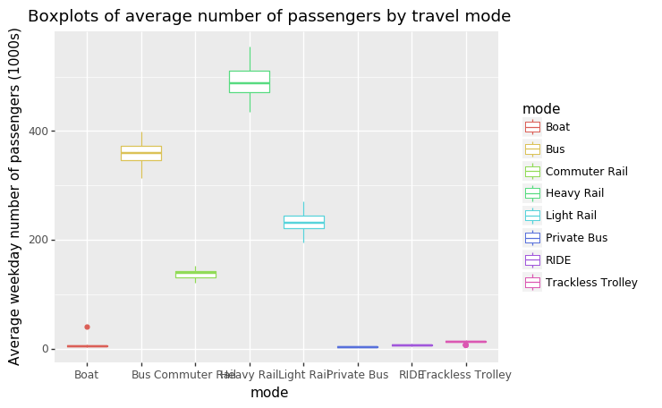

```python
from plotnine import *
#
fig = (
ggplot(mbta3, aes(x = 'mode', y = 'NrPassengers', color = 'mode'))
 + geom_boxplot()
 + ylab("Average weekday number of passengers (1000s)")
 + ggtitle("Boxplots of average number of passengers by travel mode")
)
fig
```

We see that the mode of transport text is too big. So we need to change this. We will add a `theme` layer to `fig`.

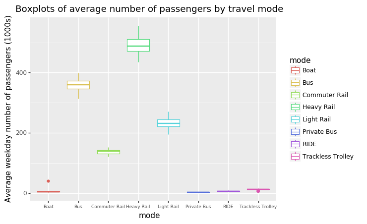

```python
fig + theme(axis_text_x = element_text(rotation = 0, ha = 'center', size = 6.5))
```

Now let us obtain the same plot using `pandas` and `matplotlib`. We must place the data for each boxplot in a column. So, we will select `mode` and `NrPassengers`, indexed by `Date` and pivot the table so that the number of passengers by each mode is in a separate column.

```python
import matplotlib.pyplot as plt
aux_bp = mbta3[['date', 'mode', 'NrPassengers']]
aux_bp = pd.pivot_table(aux_bp, index= 'date', columns = 'mode', values = 'NrPassengers')
aux_bp.head()
```

| mode date | Boat | Bus | Commuter Rail | Heavy Rail | Light Rail | Private Bus | RIDE | Trackless Trolley |
| --- | --- | --- | --- | --- | --- | --- | --- | --- |
| 2007-01-01 | 4.0 | 335.819 | 142.2 | 435.294 | 227.231 | 4.772 | 4.9 | 12.757 |
| 2007-02-01 | 3.6 | 338.675 | 138.5 | 448.271 | 240.262 | 4.417 | 5.0 | 12.913 |
| 2007-03-01 | 40.0 | 339.867 | 137.7 | 458.583 | 241.444 | 4.574 | 5.5 | 13.057 |
| 2007-04-01 | 4.3 | 352.162 | 139.5 | 472.201 | 255.557 | 4.542 | 5.4 | 13.444 |
| 2007-05-01 | 4.9 | 354.367 | 139.0 | 474.579 | 248.262 | 4.768 | 5.4 | 13.479 |

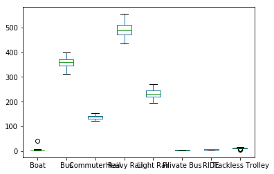

```python
aux_bp.plot.box()
plt.show()
```

We can see that most trips were made by heavy rail, bus, light rail and commuter rail, in descending order The number of passengers are on a different scale for boat, private bus and trackless trolley and their corresponding boxplots are difficult to visualise in the above plot so we will plot them separately below. We can nevertheless see some circles in the boat and trackless trolley boxplots indicating some unusual values.

Boxplot using `plotnine`

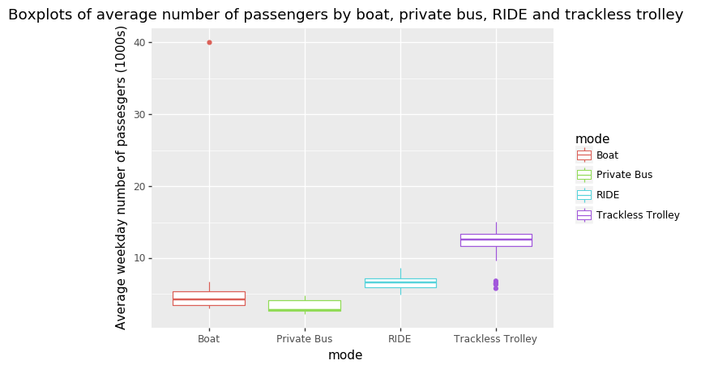

```python
aux = mbta3[ mbta3['mode'].isin(['Boat', 'Private Bus', 'RIDE', 'Trackless Trolley']) ]
#
fig = (
ggplot(aux, aes(x = 'mode' , y = 'NrPassengers', color = 'mode'))
 + geom_boxplot()
 + ylab("Average weekday number of passesgers (1000s)")
 + ggtitle("Boxplots of average number of passengers by boat, private bus, RIDE and trackless trolley")
 )
print(fig)
```

Boxplot using `pandas` and `matplotlib`

```python
#aux_bp1 contains the data only for boat, private bus, RIDE and trackless trolley.
aux_bp1 = aux_bp[ ['Boat', 'Private Bus', 'RIDE', 'Trackless Trolley'] ]
aux_bp1.head()
```

| mode date | Boat | Private Bus | RIDE | Trackless Trolley |
| --- | --- | --- | --- | --- |
| 2007-01-01 | 4.0 | 4.772 | 4.9 | 12.757 |
| 2007-02-01 | 3.6 | 4.417 | 5.0 | 12.913 |
| 2007-03-01 | 40.0 | 4.574 | 5.5 | 13.057 |
| 2007-04-01 | 4.3 | 4.542 | 5.4 | 13.444 |
| 2007-05-01 | 4.9 | 4.768 | 5.4 | 13.479 |

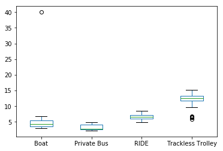

```python
aux_bp1.plot.box()
plt.show()
```

There is a very large observation for Boat. Let us find out when it was observed.

```python
#pb contains NrPassengers by boat only
pb = aux_bp1['Boat']
aux_bp1[ aux_bp1.Boat == max(pb) ]
```

| mode date | Boat | Private Bus | RIDE | Trackless Trolley |
| --- | --- | --- | --- | --- |
| 2007-03-01 | 40.0 | 4.574 | 5.5 | 13.057 |

The unusual observation occurred in March 2007. Looking at the distribution of the other values of number of passengers who traveled by boat

```python
pb1 = pb[pb < max(pb)]
pb1.describe()
```

```
count    57.000000
mean      4.455123
std       1.134642
min       2.985000
25%       3.488000
50%       4.285000
75%       5.189000
max       6.733000
Name: Boat, dtype: float64
```

and taking into account that no big event happened in Boston during that month, we conclude that it's quite likely the person who entered the data added an extra zero. So, we change this value to 4. This should be checked with data originators and must be reported.

```python
mbta3.loc[ (mbta3['mode'] == 'Boat') & (mbta3['NrPassengers'] == 40) , 'NrPassengers' ] = 4
mbta3.loc[mbta3['mode'] == 'Boat', 'NrPassengers'].describe()
```

```
count    58.000000
mean      4.447276
std       1.126232
min       2.985000
25%       3.494000
50%       4.268000
75%       5.178000
max       6.733000
Name: NrPassengers, dtype: float64
```

Let us see the boxplots again.

Boxplots using `plotnine`

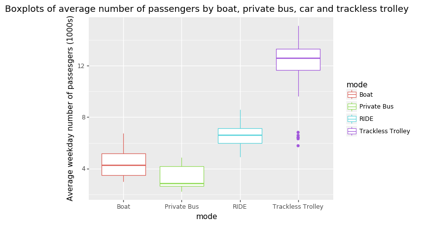

```python
aux = mbta3[ mbta3['mode'].isin(['Boat', 'Private Bus', 'RIDE', 'Trackless Trolley']) ]
#
fig = (
ggplot(aux, aes(x = 'mode' , y = 'NrPassengers', color = 'mode'))
 + geom_boxplot()
 + ylab("Average weekday number of passesgers (1000s)")
 + ggtitle("Boxplots of average number of passengers by boat, private bus, car and trackless trolley")
)
print(fig)
```

Boxplots using pandas and matplotlib

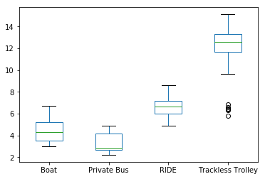

```python
import matplotlib.pyplot as plt
aux_bp = mbta3[['date', 'mode', 'NrPassengers']]
aux_bp = pd.pivot_table(aux_bp, index= 'date', columns = 'mode', values = 'NrPassengers')
#aux_bp1 contains the data only for boat, private bus, RIDE and trackless trolley.
aux_bp1 = aux_bp[ ['Boat', 'Private Bus', 'RIDE', 'Trackless Trolley'] ]
aux_bp1.plot.box()
plt.show()
```

There are some unusually low values for the number of passengers travelling by trackless trolley.

```python
#this is all the data for trackless trolley only
trtr = mbta3[mbta3['mode'] == 'Trackless Trolley']
aux = trtr.sort_values('NrPassengers')
aux.head(n=10)
```

|  | mode | NrPassengers | year | month | day | date |
| --- | --- | --- | --- | --- | --- | --- |
| 383 | Trackless Trolley | 5.777 | 2010 | 12 | 1 | 2010-12-01 |
| 351 | Trackless Trolley | 6.316 | 2010 | 8 | 1 | 2010-08-01 |
| 375 | Trackless Trolley | 6.415 | 2010 | 11 | 1 | 2010-11-01 |
| 359 | Trackless Trolley | 6.436 | 2010 | 9 | 1 | 2010-09-01 |
| 343 | Trackless Trolley | 6.584 | 2010 | 7 | 1 | 2010-07-01 |
| 367 | Trackless Trolley | 6.819 | 2010 | 10 | 1 | 2010-10-01 |
| 207 | Trackless Trolley | 9.645 | 2009 | 2 | 1 | 2009-02-01 |
| 439 | Trackless Trolley | 11.060 | 2011 | 7 | 1 | 2011-07-01 |
| 447 | Trackless Trolley | 11.091 | 2011 | 8 | 1 | 2011-08-01 |
| 391 | Trackless Trolley | 11.104 | 2011 | 1 | 1 | 2011-01-01 |

We note that all the unusually low observations for trackless trolley occurred in the second semester of 2010. So, it is likely there is a reason for that, the low observed averages are not errors. We should be aware of these values but not remove them for the moment.

Now that we have tidied up the data set we can visualise it. We will incorporate the time dimension in these plots.

First let us create a new variable, `date`.

```python
#create a column named day with 1s
mbta3 = mbta3.assign(day = 1)
mbta3['date'] = pd.to_datetime(mbta3[['year', 'month', 'day']])
mbta3.head()
```

|  | mode | NrPassengers | year | month | day | date |
| --- | --- | --- | --- | --- | --- | --- |
| 0 | Boat | 4.000 | 2007 | 1 | 1 | 2007-01-01 |
| 1 | Bus | 335.819 | 2007 | 1 | 1 | 2007-01-01 |
| 2 | Commuter Rail | 142.200 | 2007 | 1 | 1 | 2007-01-01 |
| 3 | Heavy Rail | 435.294 | 2007 | 1 | 1 | 2007-01-01 |
| 4 | Light Rail | 227.231 | 2007 | 1 | 1 | 2007-01-01 |

```python
mbta3.dtypes
```

```
mode                    object
NrPassengers           float64
year                     int64
month                    int64
day                      int64
date            datetime64[ns]
dtype: object
```

Time plots in `plotnine`

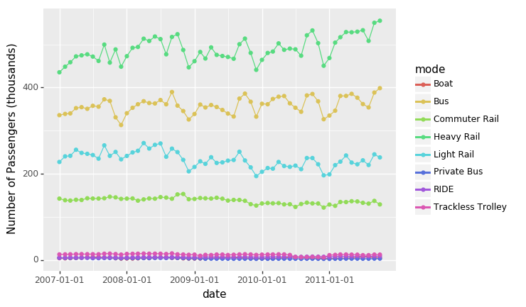

```python
fig = (
 ggplot(mbta3, aes(x = 'date', y = 'NrPassengers', color = 'mode'))
 +geom_line()
 + geom_point()
 + ylab("Number of Passengers (thousands)")
  )
fig
```

Time plot using `pandas` and `matplotlib`

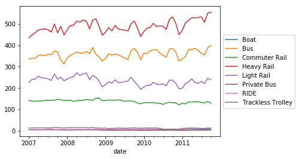

```python
pl = aux_bp.plot()
# Put a legend to the right of the current axis
pl.legend(loc='center left', bbox_to_anchor=(1, 0.5))
plt.show()
```

Again, note the very different scales for the data corresponding to the number of passengers travelling by boat, RIDE, trackless trolley and private bus. Due to that difference, it is difficult to visualise the time trends of these data. So, we will split the plots for those two subsets of mode of transportation.

Time plot using `plotnine`

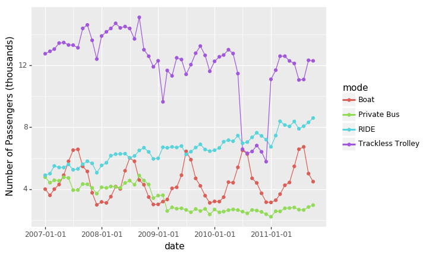

```python
#aux has already been defined but here it goes again
aux = mbta3[ mbta3['mode'].isin(['Boat', 'Private Bus', 'RIDE', 'Trackless Trolley']) ]
fig = (
ggplot(aux, aes(x = 'date', y = 'NrPassengers', color = 'mode'))
 + geom_line()
 + geom_point()
 + ylab("Number of Passengers (thousands)")
  )
 #
print(fig)
```

Time plot using `pandas` and `matplotlib`

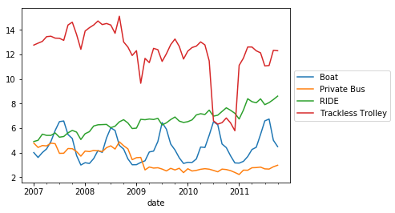

```python
#we have already defined aux_bp1
aux_bp1 = aux_bp[ ['Boat', 'Private Bus', 'RIDE', 'Trackless Trolley'] ]
pl = aux_bp1.plot()
# Put a legend to the right of the current axis
pl.legend(loc='center left', bbox_to_anchor=(1, 0.5))
plt.show()
```

Note the strong seasonal component in number of passengers travelling by boat and how the use of that mode of transportation is always highest during summer months and lowest during winter time. It was somewhat lower during 2008. The use of transportation provided by RIDE (for people with an impediment who cannot access other ways of transportation) seems to be steadily increasing during time. The use of private bus and trackless trolley had a sharp decrease since 2009 and something unusual made the use of trackless trolley dramatically decrease in the second half of 2010.

Now, let us explore the other modes of transportation.

Time plot using `plotnine`

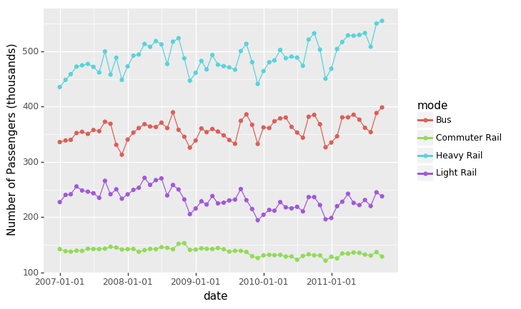

```python
#aux has already been defined but here it goes again
aux2 = mbta3[ mbta3['mode'].isin(['Bus', 'Commuter Rail', 'Heavy Rail', 'Light Rail']) ]
fig = (
ggplot(aux2, aes(x = 'date', y = 'NrPassengers', color = 'mode'))
 +  geom_line()
 +  geom_point()
 + ylab("Number of Passengers (thousands)")
 )
print(fig)
```

Time plots in `pandas` and `matplotlib`

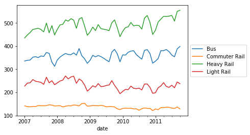

```python
aux_bp2 = aux_bp[ ['Bus', 'Commuter Rail', 'Heavy Rail', 'Light Rail'] ]
pl = aux_bp2.plot()
# Put a legend to the right of the current axis
pl.legend(loc='center left', bbox_to_anchor=(1, 0.5))
plt.show()
```

We observe that the number of passengers travelling by light and commuter rail has decreased since 2009, whilst there seems to be an upwards trend on number of passengers travelling by heavy rail and perhaps by bus as well.